# Performance Summary

For this problem, I've tried 3 model approaches to build the convultional network.

model 1: Build the network without using any pre-trained model, set epoch 64, scoring 2.16 in Private Score  
model 2: Build network with keras ResNet50V2, set epoch 30, scoring 1.88 in Private Score  
model 3: Build network with keras Xception, set epoch 30, scoring 1.24 in Private Score

The below code is from the Xception model version, the settings and architecture for other 2 models can be checked in the appendix

# Load data

1. Load the dataset from kaggle api and unzip
2. Here, I sub-sample 80% of training data to lower the RAM consumption; hence there would be 10,000 for each category
3. Declare the input image dimension as 128x128, with 3 channels (colored)

```python
#Import some packages to use
import cv2
import numpy as np
import pandas as pd

import matplotlib.pyplot as plt
%matplotlib inline

#To see our directory
import os
import random
import gc   #Gabage collector for cleaning deleted data from memory
```

```python
import os

# Set Kaggle API credentials
os.environ['KAGGLE_USERNAME'] = 'yenchenhsu'
os.environ['KAGGLE_KEY'] = '2654121bcbde9a8d683d47def584db39'

# Use the Kaggle API to download the dataset
!kaggle competitions download -c dogs-vs-cats-redux-kernels-edition
```

```
Downloading dogs-vs-cats-redux-kernels-edition.zip to /content
 98% 801M/814M [00:07<00:00, 151MB/s]
100% 814M/814M [00:07<00:00, 111MB/s]
```

```python
import zipfile

with zipfile.ZipFile('dogs-vs-cats-redux-kernels-edition.zip', 'r') as zip_ref:
    zip_ref.extractall('dataset')
```

```python
import os

dataset_dir = 'dataset'
contents = os.listdir(dataset_dir)
print(contents)
```

```
['train.zip', 'sample_submission.csv', 'test.zip']
```

```python
! unzip dataset/train.zip
! unzip dataset/test.zip
```

```python
# create destination directories for cats and dogs
!mkdir dataset/cat_images
!mkdir dataset/dog_images

# move cat images to the cat_images directory
!mv train/cat.*.jpg dataset/cat_images/

# move dog images to the dog_images directory
!mv train/dog.*.jpg dataset/dog_images/
```

```python
! ls dataset/cat_images | head -n 10
```

```
cat.0.jpg
cat.10000.jpg
cat.10001.jpg
cat.10002.jpg
cat.10003.jpg
cat.10004.jpg
cat.10005.jpg
cat.10006.jpg
cat.10007.jpg
cat.10008.jpg
```

```python
! ls dataset/dog_images/ | head -n 10
```

```
dog.0.jpg
dog.10000.jpg
dog.10001.jpg
dog.10002.jpg
dog.10003.jpg
dog.10004.jpg
dog.10005.jpg
dog.10006.jpg
dog.10007.jpg
dog.10008.jpg
```

```python
import os
import random
import shutil

# Define the paths to your cat and dog image directories
cat_images_dir = 'dataset/cat_images'
dog_images_dir = 'dataset/dog_images'

# Define the paths where you want to save the sampled data
sampled_cat_images_dir = 'dataset/sample_cat_images'
sampled_dog_images_dir = 'dataset/sample_dog_images'

# Define the number of samples you want from each category
num_samples_per_category = 10000

# Create the directories for sampled cat and dog images
os.makedirs(sampled_cat_images_dir, exist_ok=True)
os.makedirs(sampled_dog_images_dir, exist_ok=True)

# Randomly sample cat images
cat_files = os.listdir(cat_images_dir)
random.shuffle(cat_files)
sampled_cat_files = cat_files[:num_samples_per_category]

# Randomly sample dog images
dog_files = os.listdir(dog_images_dir)
random.shuffle(dog_files)
sampled_dog_files = dog_files[:num_samples_per_category]

# Copy the sampled cat images to the sample_cat_images directory
for filename in sampled_cat_files:
    src_path = os.path.join(cat_images_dir, filename)
    dest_path = os.path.join(sampled_cat_images_dir, filename)
    shutil.copy(src_path, dest_path)

# Copy the sampled dog images to the sample_dog_images directory
for filename in sampled_dog_files:
    src_path = os.path.join(dog_images_dir, filename)
    dest_path = os.path.join(sampled_dog_images_dir, filename)
    shutil.copy(src_path, dest_path)
```

```python
# Define the paths to the sampled cat and dog image directories
sampled_cat_images_dir = 'dataset/sample_cat_images'
sampled_dog_images_dir = 'dataset/sample_dog_images'

# List the files in the sampled_cat_images_dir directory
num_cat_files = len(os.listdir(sampled_cat_images_dir))
print(f"Number of Sampled Cat Images: {num_cat_files}")
num_dog_files = len(os.listdir(sampled_dog_images_dir))
print(f"Number of Sampled Dog Images: {num_dog_files}")
```

```
Number of Sampled Cat Images: 10000
Number of Sampled Dog Images: 10000
```

```python
del cat_files
del dog_files
gc.collect()   #collect garbage to save memory
```

```
4
```

```python
# Get the list of image file paths from each directory
cat_image_paths = [os.path.join(sampled_cat_images_dir, filename) for filename in os.listdir(sampled_cat_images_dir)]
dog_image_paths = [os.path.join(sampled_dog_images_dir, filename) for filename in os.listdir(sampled_dog_images_dir)]

# Combine the two lists into a single list
train_imgs = cat_image_paths + dog_image_paths
```

```python
#shuffle the training images
random.shuffle(train_imgs)
```

```python
#Lets declare our image dimensions
#we are using coloured images.
nrows = 128
ncolumns = 128
channels = 3

#A function to read and process the images to an acceptable format for our model
def read_and_process_image(list_of_images):
    X = [] # images
    y = [] # labels

    for image in list_of_images:
        X.append(cv2.resize(cv2.imread(image, cv2.IMREAD_COLOR), (nrows,ncolumns), interpolation=cv2.INTER_CUBIC))
        #get the labels
        if 'dog' in image:
            y.append(0)
        elif 'cat' in image:
            y.append(1)

    return X, y
```

```python
X, y = read_and_process_image(train_imgs)
```

```python
unique, counts = np.unique(y, return_counts=True)
for label, count in zip(unique, counts):
    print("Label:", label, "Count:", count)
```

```
Label: 0 Count: 10000
Label: 1 Count: 10000
```

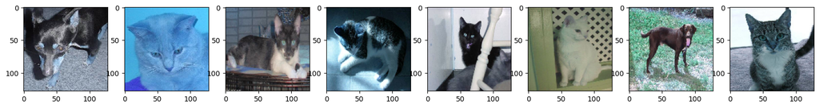

```python
#Lets view some of the pics
plt.figure(figsize=(20,10))
columns = 8
for i in range(columns):
    plt.subplot(5 // columns + 1, columns, i + 1)
    plt.imshow(X[i])
```

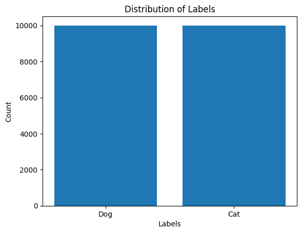

```python
import matplotlib.pyplot as plt

labels, counts = np.unique(y, return_counts=True)

# Plotting
plt.bar(labels, counts, tick_label=['Dog', 'Cat'])
plt.xlabel('Labels')
plt.ylabel('Count')
plt.title('Distribution of Labels')
plt.show()
```

# Create Network Architecture

```python
from tensorflow.keras.models import Sequential
from tensorflow.keras.layers import Flatten
from tensorflow.keras.layers import Dense
from tensorflow.keras.layers import Conv2D
from tensorflow.keras.layers import MaxPooling2D
from tensorflow.keras.callbacks import TensorBoard
from keras.layers import Dropout
from keras import optimizers
from tensorflow import keras
from tensorflow.keras.applications import ResNet50V2
```

```python
from warnings import filterwarnings
filterwarnings('ignore')
```

```python
X = np.array(X)
y = np.array(y)
```

```python
from sklearn.model_selection import train_test_split
X_train, X_val, y_train, y_val = train_test_split(X, y, test_size=0.2, random_state=2)
```

```python
print("Shape of train images is:", X_train.shape)
print("Shape of validation images is:", X_val.shape)
print("Shape of labels is:", y_train.shape)
print("Shape of labels is:", y_val.shape)
```

```
Shape of train images is: (16000, 128, 128, 3)
Shape of validation images is: (4000, 128, 128, 3)
Shape of labels is: (16000,)
Shape of labels is: (4000,)
```

```python
#clear memory
del X
del y
gc.collect()
```

```
43
```

```python
ntrain = len(X_train)
nval = len(X_val)
batch_size = 32
```

```python
from keras.models import Sequential
from keras.layers import Conv2D, MaxPooling2D, Dropout, Flatten, Dense, Activation, BatchNormalization
from tensorflow.keras.applications import ResNet50V2
from tensorflow.keras.models import Model
from tensorflow.keras.applications import Xception


from tensorflow.keras import layers, models

Xception = Xception(include_top=False, weights='imagenet', input_shape=(128,128,3))
for layer in Xception.layers:
    layer.trainable = False

# build the complete model
model_res = Xception.output
model_res = layers.GlobalAveragePooling2D()(model_res)
model_res = layers.Dense(32, activation='relu')(model_res)
model_res = layers.Dropout(0.5)(model_res)
model_res = layers.Dense(64, activation='relu')(model_res)
model_res = layers.Dropout(0.5)(model_res)
model_res = layers.Dense(128, activation='relu')(model_res)
model_res = layers.Dropout(0.5)(model_res)
model_res = layers.Dense(256, activation='relu')(model_res)
model_res = layers.Dropout(0.5)(model_res)
predictions = layers.Dense(1, activation='sigmoid')(model_res)
model = Model(inputs = Xception.input, outputs = predictions)
```

```python
model.compile(optimizer = 'adam', loss = 'binary_crossentropy', metrics = ['accuracy'])
```

```python
model.summary()
```

```
Model: "model_2"
__________________________________________________________________________________________________
 Layer (type)                Output Shape                 Param #   Connected to
==================================================================================================
 input_8 (InputLayer)        [(None, 128, 128, 3)]        0         []

 block1_conv1 (Conv2D)       (None, 63, 63, 32)           864       ['input_8[0][0]']

 block1_conv1_bn (BatchNorm  (None, 63, 63, 32)           128       ['block1_conv1[0][0]']
 alization)

 block1_conv1_act (Activati  (None, 63, 63, 32)           0         ['block1_conv1_bn[0][0]']
 on)

 block1_conv2 (Conv2D)       (None, 61, 61, 64)           18432     ['block1_conv1_act[0][0]']

 block1_conv2_bn (BatchNorm  (None, 61, 61, 64)           256       ['block1_conv2[0][0]']
 alization)

 block1_conv2_act (Activati  (None, 61, 61, 64)           0         ['block1_conv2_bn[0][0]']
 on)

 block2_sepconv1 (Separable  (None, 61, 61, 128)          8768      ['block1_conv2_act[0][0]']
 Conv2D)

 block2_sepconv1_bn (BatchN  (None, 61, 61, 128)          512       ['block2_sepconv1[0][0]']
 ormalization)

 block2_sepconv2_act (Activ  (None, 61, 61, 128)          0         ['block2_sepconv1_bn[0][0]']
 ation)

 block2_sepconv2 (Separable  (None, 61, 61, 128)          17536     ['block2_sepconv2_act[0][0]']
 Conv2D)

 block2_sepconv2_bn (BatchN  (None, 61, 61, 128)          512       ['block2_sepconv2[0][0]']
 ormalization)

 conv2d_6 (Conv2D)           (None, 31, 31, 128)          8192      ['block1_conv2_act[0][0]']

 block2_pool (MaxPooling2D)  (None, 31, 31, 128)          0         ['block2_sepconv2_bn[0][0]']
```

[output cut: 366 more lines]

```
 dense_17 (Dense)            (None, 128)                  8320      ['dropout_14[0][0]']

 dropout_15 (Dropout)        (None, 128)                  0         ['dense_17[0][0]']

 dense_18 (Dense)            (None, 256)                  33024     ['dropout_15[0][0]']

 dropout_16 (Dropout)        (None, 256)                  0         ['dense_18[0][0]']

 dense_19 (Dense)            (None, 1)                    257       ['dropout_16[0][0]']

==================================================================================================
Total params: 20970761 (80.00 MB)
Trainable params: 109281 (426.88 KB)
Non-trainable params: 20861480 (79.58 MB)
__________________________________________________________________________________________________
```

```python
from keras.preprocessing.image import ImageDataGenerator

train_datagen = ImageDataGenerator(rescale=1./255,
                                   featurewise_center=True,
                                   featurewise_std_normalization=True,
                                    rotation_range=20,
                                    width_shift_range=0.2,
                                    height_shift_range=0.2,
                                    shear_range=0.2,
                                    zoom_range=0.2,
                                    horizontal_flip=True,)

val_datagen = ImageDataGenerator(rescale=1./255)
```

```python
train_generator = train_datagen.flow(X_train, y_train, batch_size=batch_size)
val_generator = val_datagen.flow(X_val, y_val, batch_size=batch_size)
```

```python
history = model.fit_generator(train_generator,
                              steps_per_epoch=ntrain // batch_size,
                              epochs=30,
                              validation_data=val_generator,
                              validation_steps=nval // batch_size)
```

```python
model.save('model_inception_epoch.keras')
```

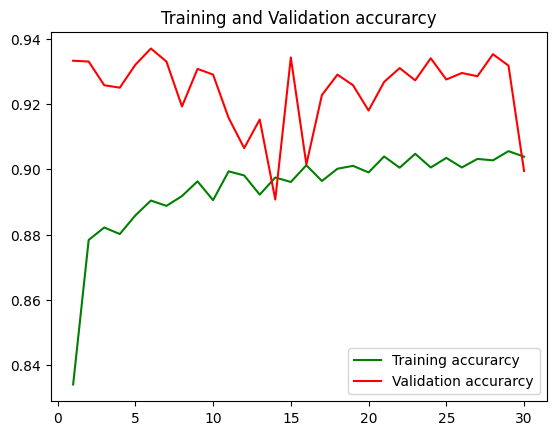

```python
acc = history.history['accuracy']
val_acc = history.history['val_accuracy']

epochs = range(1, len(acc) + 1)

#Train and validation accuracy
plt.plot(epochs, acc, 'g', label='Training accurarcy')
plt.plot(epochs, val_acc, 'r', label='Validation accurarcy')
plt.title('Training and Validation accurarcy')
plt.legend()
plt.figure()
plt.show()
```

```python
#!pip install visualkeras
```

[output not shown]

## Visualize the model structure with visualkeras

```python
import visualkeras

# Visualize the model
visualkeras.layered_view(model, to_file='model_visualization.png').show()
```

[figure not shown]

```python
from tensorflow.python.keras.layers import Dense, Conv2D, Flatten, Dropout, MaxPooling2D, ZeroPadding2D
from collections import defaultdict

from PIL import ImageFont
font = ImageFont.load_default()
color_map = defaultdict(dict)
color_map[Conv2D]['fill'] = 'orange'
color_map[ZeroPadding2D]['fill'] = 'gray'
color_map[Dropout]['fill'] = 'pink'
color_map[MaxPooling2D]['fill'] = 'red'
color_map[Dense]['fill'] = 'green'
color_map[Flatten]['fill'] = 'teal'

visualkeras.layered_view(model, color_map=color_map,legend=True, font=font)
```

## Apply to testing data

```python
!mkdir dataset/test
!mv test/* dataset/test
```

```
mkdir: cannot create directory ‘dataset/test’: File exists
mv: cannot stat 'test/*': No such file or directory
```

```python
!ls dataset/test head -n 10
```

[output not shown]

[output cut: 12449 more lines]

[output not shown]

```python
test_dir = 'dataset/test'
test_imgs = ['dataset/test/{}'.format(i) for i in os.listdir(test_dir)]
```

```python
X_test, y_test = read_and_process_image(test_imgs[0:10]) #Y_test in this case will be empty.
x = np.array(X_test)
test_datagen = ImageDataGenerator(rescale=1./255)
```

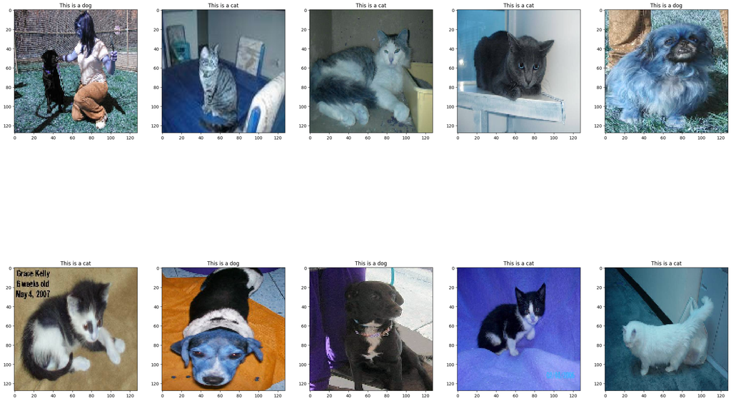

```python
i = 0
text_labels = []
plt.figure(figsize=(30,20))

columns = 5
for batch in test_datagen.flow(x, batch_size=1):
    pred = model.predict(batch)
    if pred > 0.5:
        text_labels.append('cat')
    else:
        text_labels.append('dog')
    plt.subplot(5 // columns + 1, columns, i + 1)
    plt.title('This is a ' + text_labels[i])
    imgplot = plt.imshow(batch[0])
    i += 1
    if i % 10 == 0:
        break
plt.show()
```

```python
X_test_output, y_test = read_and_process_image(test_imgs)
```

```python
x = np.array(X_test_output)
test_datagen = ImageDataGenerator(rescale=1./255)

i = 0
id = []
label = []

for batch in test_datagen.flow(x, batch_size=1):
    i+=1
    pred = model.predict(batch).item()
    label.append(pred)
    id.append(i)

    # I update i at the beginning and do the break at the end of the loop
    # s.t. it will break after processing the last image in testing set
    if i == len(X_test_output):
        break
```

[output not shown]

```python
data = {'id': id, 'label': label}
result = pd.DataFrame(data)

result.head(5)
```

|  | id | label |
| --- | --- | --- |
| 0 | 1 | 0.287054 |
| 1 | 2 | 0.217154 |
| 2 | 3 | 0.153079 |
| 3 | 4 | 0.763498 |
| 4 | 5 | 0.434868 |

```python
result.to_csv('catsanddogs_1202_xception.csv', index=False)
```

```python
from google.colab import files
files.download('catsanddogs_1202_xception.csv')
```

## Appendix 1. Self-built model

Trained with 64 epoch, getting validation accuracy 89% at the last epoch, scoring 2.16 on private leaderboard

```python
from keras import layers
from keras import models
from keras import optimizers
from keras.preprocessing.image import ImageDataGenerator
from tensorflow.keras.models import Sequential
from tensorflow.keras.layers import Conv2D, MaxPooling2D, BatchNormalization, Dropout, Dense, Flatten
from tensorflow.keras.callbacks import EarlyStopping, ModelCheckpoint, ReduceLROnPlateau , CSVLogger
model = Sequential()

model.add(Conv2D(32, (3, 3), activation='relu', input_shape=(128, 128, 3)))
model.add(BatchNormalization())
model.add(MaxPooling2D(pool_size=(2, 2)))
model.add(Conv2D(64, (3, 3), activation='relu'))
model.add(BatchNormalization())
model.add(MaxPooling2D(pool_size=(2, 2)))
model.add(Conv2D(128, (3, 3), activation='relu'))
model.add(BatchNormalization())
model.add(MaxPooling2D(pool_size=(2, 2)))
model.add(Conv2D(256, (3, 3), activation='relu'))
model.add(BatchNormalization())
model.add(MaxPooling2D(pool_size=(2, 2)))
model.add(layers.Flatten())
model.add(layers.Dropout(0.5))
model.add(layers.Dense(512, activation='relu'))
model.add(layers.Dense(1, activation='sigmoid'))

model.summary()
```

```
2023-12-02 12:46:54.085566: I tensorflow/core/platform/cpu_feature_guard.cc:182] This TensorFlow binary is optimized to use available CPU instructions in performance-critical operations.
To enable the following instructions: AVX2 AVX512F AVX512_VNNI FMA, in other operations, rebuild TensorFlow with the appropriate compiler flags.
```

```
Model: "sequential"
_________________________________________________________________
 Layer (type)                Output Shape              Param #
=================================================================
 conv2d (Conv2D)             (None, 126, 126, 32)      896

 batch_normalization (Batch  (None, 126, 126, 32)      128
 Normalization)

 max_pooling2d (MaxPooling2  (None, 63, 63, 32)        0
 D)

 conv2d_1 (Conv2D)           (None, 61, 61, 64)        18496

 batch_normalization_1 (Bat  (None, 61, 61, 64)        256
 chNormalization)

 max_pooling2d_1 (MaxPoolin  (None, 30, 30, 64)        0
 g2D)

 conv2d_2 (Conv2D)           (None, 28, 28, 128)       73856

 batch_normalization_2 (Bat  (None, 28, 28, 128)       512
 chNormalization)

 max_pooling2d_2 (MaxPoolin  (None, 14, 14, 128)       0
 g2D)

 conv2d_3 (Conv2D)           (None, 12, 12, 256)       295168

 batch_normalization_3 (Bat  (None, 12, 12, 256)       1024
 chNormalization)

 max_pooling2d_3 (MaxPoolin  (None, 6, 6, 256)         0
 g2D)

 flatten (Flatten)           (None, 9216)              0

 dropout (Dropout)           (None, 9216)              0

 dense (Dense)               (None, 512)               4719104

 dense_1 (Dense)             (None, 1)                 513

=================================================================
Total params: 5109953 (19.49 MB)
Trainable params: 5108993 (19.49 MB)
Non-trainable params: 960 (3.75 KB)
_________________________________________________________________
```

## Appendix 2. ResNet50V2

Trained with 30 epoch, getting validation accuracy 95% at the last epoch, scoring 1.88 on private leaderboard

```python
from keras.models import Sequential
from keras.layers import Conv2D, MaxPooling2D, Dropout, Flatten, Dense, Activation, BatchNormalization
from tensorflow.keras.applications import ResNet50V2
from tensorflow.keras.models import Model


from tensorflow.keras import layers, models

resnet_50v2 = ResNet50V2(include_top=False, weights='imagenet', input_shape=(128,128,3))
for layer in resnet_50v2.layers:
    layer.trainable = False

# build the complete model
model_res = resnet_50v2.output
model_res = layers.GlobalAveragePooling2D()(model_res)
model_res = layers.Dense(32, activation='relu')(model_res)
model_res = layers.Dropout(0.5)(model_res)
model_res = layers.Dense(64, activation='relu')(model_res)
model_res = layers.Dropout(0.5)(model_res)
model_res = layers.Dense(128, activation='relu')(model_res)
model_res = layers.Dropout(0.5)(model_res)
model_res = layers.Dense(256, activation='relu')(model_res)
model_res = layers.Dropout(0.5)(model_res)
predictions = layers.Dense(1, activation='sigmoid')(model_res)
model = Model(inputs = resnet_50v2.input, outputs = predictions)
```

```
Downloading data from https://storage.googleapis.com/tensorflow/keras-applications/resnet/resnet50v2_weights_tf_dim_ordering_tf_kernels_notop.h5
```

```python
model.summary()
```

```
Model: "model"
__________________________________________________________________________________________________
 Layer (type)                Output Shape                 Param #   Connected to
==================================================================================================
 input_1 (InputLayer)        [(None, 128, 128, 3)]        0         []

 conv1_pad (ZeroPadding2D)   (None, 134, 134, 3)          0         ['input_1[0][0]']

 conv1_conv (Conv2D)         (None, 64, 64, 64)           9472      ['conv1_pad[0][0]']

 pool1_pad (ZeroPadding2D)   (None, 66, 66, 64)           0         ['conv1_conv[0][0]']

 pool1_pool (MaxPooling2D)   (None, 32, 32, 64)           0         ['pool1_pad[0][0]']

 conv2_block1_preact_bn (Ba  (None, 32, 32, 64)           256       ['pool1_pool[0][0]']
 tchNormalization)

 conv2_block1_preact_relu (  (None, 32, 32, 64)           0         ['conv2_block1_preact_bn[0][0]
 Activation)                                                        ']

 conv2_block1_1_conv (Conv2  (None, 32, 32, 64)           4096      ['conv2_block1_preact_relu[0][
 D)                                                                 0]']

 conv2_block1_1_bn (BatchNo  (None, 32, 32, 64)           256       ['conv2_block1_1_conv[0][0]']
 rmalization)

 conv2_block1_1_relu (Activ  (None, 32, 32, 64)           0         ['conv2_block1_1_bn[0][0]']
 ation)

 conv2_block1_2_pad (ZeroPa  (None, 34, 34, 64)           0         ['conv2_block1_1_relu[0][0]']
 dding2D)

 conv2_block1_2_conv (Conv2  (None, 32, 32, 64)           36864     ['conv2_block1_2_pad[0][0]']
 D)

 conv2_block1_2_bn (BatchNo  (None, 32, 32, 64)           256       ['conv2_block1_2_conv[0][0]']
 rmalization)

 conv2_block1_2_relu (Activ  (None, 32, 32, 64)           0         ['conv2_block1_2_bn[0][0]']
 ation)
```

[output cut: 540 more lines]

```
 dense_4 (Dense)             (None, 128)                  8320      ['dropout_2[0][0]']

 dropout_3 (Dropout)         (None, 128)                  0         ['dense_4[0][0]']

 dense_5 (Dense)             (None, 256)                  33024     ['dropout_3[0][0]']

 dropout_4 (Dropout)         (None, 256)                  0         ['dense_5[0][0]']

 dense_6 (Dense)             (None, 1)                    257       ['dropout_4[0][0]']

==================================================================================================
Total params: 23674081 (90.31 MB)
Trainable params: 109281 (426.88 KB)
Non-trainable params: 23564800 (89.89 MB)
__________________________________________________________________________________________________
```